# bivariate statistics: comparing [two things]

# Bivariate: simplest multivariate case

## Normal and size ‘n’

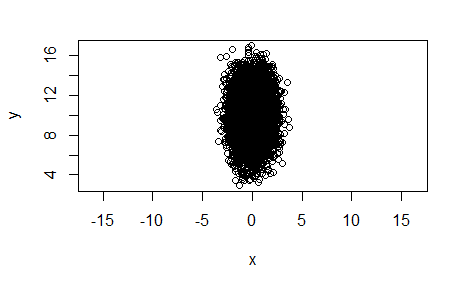

```r
x = rnorm( (n=10000), mean = 0, sd = 1);
y = rnorm(n, mean = 10, sd = 2);
plot(x,y, asp=1);
```

```r
stem(x);
```

```
  The decimal point is at the |

  -3 | 65
  -3 | 43222100
  -2 | 9999999888888887777777777666666666666666665555555555555555
  -2 | 44444444444444444443333333333333333333333332222222222222222222222222+91
  -1 | 99999999999999999999999999999999999999999999999999999999999999888888+440
  -1 | 44444444444444444444444444444444444444444444444444444444444444444444+863
  -0 | 99999999999999999999999999999999999999999999999999999999999999999999+1466
  -0 | 44444444444444444444444444444444444444444444444444444444444444444444+1699
   0 | 00000000000000000000000000000000000000000000000000000000000000000000+1628
   0 | 55555555555555555555555555555555555555555555555555555555555555555555+1462
   1 | 00000000000000000000000000000000000000000000000000000000000000000000+909
   1 | 55555555555555555555555555555555555555555555555555555555555555555555+399
   2 | 00000000000000000000000000000000000000000000000000000000001111111111+113
   2 | 55555555555555555566666666677777777777788888888999
   3 | 000112223
   3 | 568
```

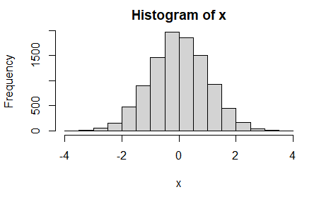

```r
hist(x);
```

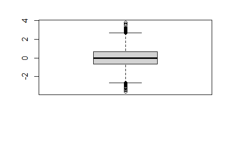

```r
boxplot(x);
```

```r
summary(x);
```

```
     Min.   1st Qu.    Median      Mean   3rd Qu.
-3.615745 -0.655868 -0.006580  0.001651  0.677168
     Max.
 3.766939
```

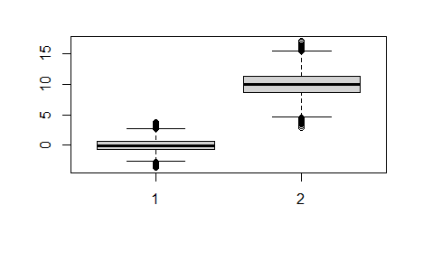

```r
boxplot(x,y);
```

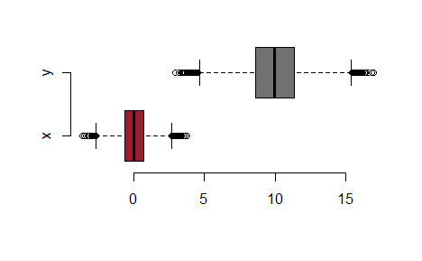

```r
# https://brand.wsu.edu/visual/colors/
wsu.crimson = "#981e32";
wsu.gray    = "#717171";

boxplot(x,y,
          horizontal=TRUE,
          names=c("x","y"),
          col=c(wsu.crimson,wsu.gray), # colors
          frame=FALSE
        );
```

```r
# why is "frame" not documented?
# why not part of "par" (... already taken)
# https://stackoverflow.com/questions/4946491/removing-the-frame-from-the-boxplot-function-in-r
```

Now, since I defined `n` the way I did, I could go back up to the top, change the value, and run again. This is “better” than copying and pasting lots of code, but “worse” than trying to write a function that will do it.

Try n=100, n=1000, n=10000 … and comment

– WRITE SOMETHING HERE – As n increases, the histogram becomes more normal, the scatterplot is more clustered (to the point of being black), and there are more dots outside of the boxplot.

# Correlation, Causation, and Independence

Informally, when we say two things “correlate” we mean there is some degree of dependence. The Pearson correlation:

## (Random) correlation

```r
# distributions = c();
# distributions = NULL;
nsim = 10000;
distributions = numeric(nsim);
for(i in 1:nsim)
  {
  # print(i);
  x = rnorm( (n=100), mean = 0, sd = 1);
  y = rnorm(n, mean = 10, sd = 2);

  myCorr = cor(x,y);
  distributions = c(distributions, myCorr);
  distributions[i] = myCorr;
  }

summary(distributions);
```

```
      Min.    1st Qu.     Median       Mean    3rd Qu.
-0.4007036 -0.0693816  0.0000638  0.0002120  0.0689651
      Max.
 0.3713091
```

```r
#?cor
cor(x,y);
```

```
[1] 0.1832159
```

Not exactly zero, but very close as the “random data” (x,y) were drawn from independent random-ness. Sometimes negative, sometimes positive. What does that mean?

## (Fixed) correlation

```r
set.seed(62629); x = rnorm( (n=100), mean = 0, sd = 1);
set.seed(62629); y = rnorm(n, mean = 10, sd = 2);
#?cor
cor(x,y);
```

```
[1] 1
```

```r
# get.seed ?
```

What happened?

## (Functional) correlation

```r
x = rnorm( (n=100), mean = 0, sd = 1);
y = 3*x + 5;
#?cor
cor(x,y);
```

```
[1] 1
```

Now what?

## (Functional) correlation?

```r
x = rnorm( (n=100), mean = 0, sd = 1);
y = 2*x^3 + 3*x + 5;
#?cor
cor(x,y);
```

```
[1] 0.9460111
```

How does “correlation” and “linearness” relate (or correlate)? Why?

Linear algebra, linear combinations, this is all the foundation of most statistical procedures.

https://en.wikipedia.org/wiki/Pearson_correlation_coefficient

## More (Functional) correlation

```r
x = rnorm( (n=100), mean = 0, sd = 1);
y = 3*x + 5;

#  doLinearRegression(x,y, ...)

#?cor
cor(x,y);
```

```
[1] 1
```

```r
reg = lm(y~x); # ?lm
summary(reg);
```

```
essentially perfect fit: summary may be unreliable
```

```
Call:
lm(formula = y ~ x)

Residuals:
       Min         1Q     Median         3Q        Max
-3.239e-15 -4.772e-16 -1.640e-16  1.002e-16  1.906e-14

Coefficients:
             Estimate Std. Error   t value Pr(>|t|)
(Intercept) 5.000e+00  2.094e-16 2.388e+16   <2e-16
x           3.000e+00  2.109e-16 1.422e+16   <2e-16

(Intercept) ***
x           ***
---
Signif. codes:
0 ‘***’ 0.001 ‘**’ 0.01 ‘*’ 0.05 ‘.’ 0.1 ‘ ’ 1

Residual standard error: 2.033e-15 on 98 degrees of freedom
Multiple R-squared:      1, Adjusted R-squared:      1
F-statistic: 2.023e+32 on 1 and 98 DF,  p-value: < 2.2e-16
```

```r
# str(summary(reg));

( reg.r2 = r2 = summary(reg)$r.squared );
```

```
essentially perfect fit: summary may be unreliable
```

```
[1] 1
```

```r
( r2.adj = summary(reg)$adj.r.squared );
```

```
essentially perfect fit: summary may be unreliable
```

```
[1] 1
```

```r
# names(summary(reg));
( reg.fit.df = summary(reg)$df );
```

```
essentially perfect fit: summary may be unreliable
```

```
[1]  2 98  2
```

```r
( reg.fit.fstatistic = summary(reg)$fstatistic );
```

```
essentially perfect fit: summary may be unreliable
```

```
       value        numdf        dendf
2.023448e+32 1.000000e+00 9.800000e+01
```

```r
( reg.fit.model.p = as.numeric( pf(reg.fit.fstatistic[1], reg.fit.fstatistic[2], reg.fit.fstatistic[3]) ) );
```

```
[1] 1
```

```r
( reg.coef = summary(reg)$coefficients[,1] );
```

```
essentially perfect fit: summary may be unreliable
```

```
(Intercept)           x
          5           3
```

```r
( reg.coef.se = summary(reg)$coefficients[,2] );
```

```
essentially perfect fit: summary may be unreliable
```

```
 (Intercept)            x
2.093990e-16 2.108994e-16
```

```r
( reg.coef.tvalue = summary(reg)$coefficients[,3] );
```

```
essentially perfect fit: summary may be unreliable
```

```
 (Intercept)            x
2.387786e+16 1.422479e+16
```

```r
( reg.coef.tvalue.prob = summary(reg)$coefficients[,4] );
```

```
essentially perfect fit: summary may be unreliable
```

```
(Intercept)           x
          0           0
```

```r
# https://astrostatistics.psu.edu/su07/R/html/grDevices/html/plotmath.html
# https://lukemiller.org/index.php/2012/10/adding-p-values-and-r-squared-values-to-a-plot-using-expression/


myMain = paste0(
    "y = ", round(reg.coef[2], 3), "x + ", round(reg.coef[1], 3), "\n",
    "F(",round(reg.fit.fstatistic[2],3), ",", round(reg.fit.fstatistic[3],3),") = ", round(reg.fit.fstatistic[1],3), ", p = ", round(reg.fit.model.p,3), "\n",
    "R^2 = ", round(reg.r2,3));

  myMin = min(x,y) - 5;
  myMax = max(x,y) + 5;
plot(x,y,
  asp=1, pty="s",
  main = myMain, col.main = "blue",
  xlim=c(myMin,myMax),
  ylim=c(myMin,myMax),
  type="p", pch=18, cex=1.75,
  col=wsu.gray);
abline(a=0,b=1, col="black");
```

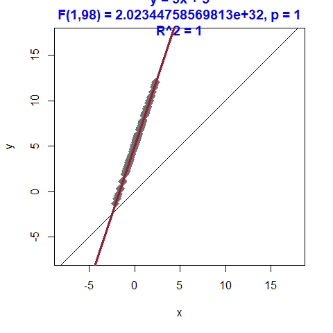

```r
abline(reg, lwd=3, col=wsu.crimson);
```

```r
print("R^2, square root:");
```

```
[1] "R^2, square root:"
```

```r
sqrt(r2);
```

```
[1] 1
```

```r
print("Correlation:");
```

```
[1] "Correlation:"
```

```r
cor(x,y);
```

```
[1] 1
```

```r
# RStudio has hijacked the "viewing" window ... wants you to use ggplot2 or change the parameters above
```

## More (Functional) correlation?

```r
x = rnorm( (n=100), mean = 0, sd = 1);
y = 2*x^3 + 3*x + 5;
#?cor
cor(x,y);
```

```
[1] 0.9285647
```

```r
reg = lm(y~x); # ?lm
summary(reg);
```

```
Call:
lm(formula = y ~ x)

Residuals:
     Min       1Q   Median       3Q      Max
-14.5705  -2.3904   0.2208   2.5909  13.2135

Coefficients:
            Estimate Std. Error t value Pr(>|t|)
(Intercept)   4.6995     0.3471   13.54   <2e-16 ***
x             8.1633     0.3296   24.77   <2e-16 ***
---
Signif. codes:
0 ‘***’ 0.001 ‘**’ 0.01 ‘*’ 0.05 ‘.’ 0.1 ‘ ’ 1

Residual standard error: 3.46 on 98 degrees of freedom
Multiple R-squared:  0.8622,    Adjusted R-squared:  0.8608
F-statistic: 613.3 on 1 and 98 DF,  p-value: < 2.2e-16
```

```r
# str(summary(reg));

( reg.r2 = r2 = summary(reg)$r.squared );
```

```
[1] 0.8622323
```

```r
( r2.adj = summary(reg)$adj.r.squared );
```

```
[1] 0.8608265
```

```r
# names(summary(reg));
( reg.fit.df = summary(reg)$df );
```

```
[1]  2 98  2
```

```r
( reg.fit.fstatistic = summary(reg)$fstatistic );
```

```
   value    numdf    dendf
613.3424   1.0000  98.0000
```

```r
( reg.fit.model.p = as.numeric( pf(reg.fit.fstatistic[1], reg.fit.fstatistic[2], reg.fit.fstatistic[3]) ) );
```

```
[1] 1
```

```r
( reg.coef = summary(reg)$coefficients[,1] );
```

```
(Intercept)           x
   4.699539    8.163319
```

```r
( reg.coef.se = summary(reg)$coefficients[,2] );
```

```
(Intercept)           x
  0.3470762   0.3296213
```

```r
( reg.coef.tvalue = summary(reg)$coefficients[,3] );
```

```
(Intercept)           x
   13.54037    24.76575
```

```r
( reg.coef.tvalue.prob = summary(reg)$coefficients[,4] );
```

```
 (Intercept)            x
3.577124e-24 5.687706e-44
```

```r
# https://astrostatistics.psu.edu/su07/R/html/grDevices/html/plotmath.html
# https://lukemiller.org/index.php/2012/10/adding-p-values-and-r-squared-values-to-a-plot-using-expression/


myMain = paste0(
    "y = ", round(reg.coef[2], 3), "x + ", round(reg.coef[1], 3), "\n",
    "F(",round(reg.fit.fstatistic[2],3), ",", round(reg.fit.fstatistic[3],3),") = ", round(reg.fit.fstatistic[1],3), ", p = ", round(reg.fit.model.p,3), "\n",
    "R^2 = ", round(reg.r2,3));

  myMin = min(x,y) - 5;
  myMax = max(x,y) + 5;
plot(x,y,
  asp=1, pty="s",
  main = myMain, col.main = "blue",
  xlim=c(myMin,myMax),
  ylim=c(myMin,myMax),
  type="p", pch=18, cex=1.75,
  col=wsu.gray);
abline(a=0,b=1, col="black");
```

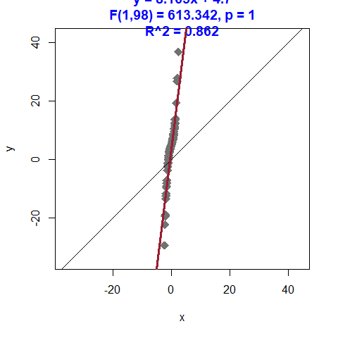

```r
abline(reg, lwd=3, col=wsu.crimson);
```

```r
print("R^2, square root:");
```

```
[1] "R^2, square root:"
```

```r
sqrt(r2);
```

```
[1] 0.9285647
```

```r
print("Correlation:");
```

```
[1] "Correlation:"
```

```r
cor(x,y);
```

```
[1] 0.9285647
```

```r
# Chunk is too long, sign that I need a function
```

# Statistically testing two “things”

Google search (images): “when to use t test vs z test”

One-variable t-test, comparing your data to a known “truth”. pH=7

## t-test (bivariate)

```r
# https://statistics.berkeley.edu/computing/r-t-tests
x = rnorm( (n=100), mean = 0, sd = 1);
y = rnorm(n, mean = 10, sd = 2);
t.test(x,y);
```

```
    Welch Two Sample t-test

data:  x and y
t = -45.519, df = 153.85, p-value < 2.2e-16
alternative hypothesis: true difference in means is not equal to 0
95 percent confidence interval:
 -10.494277  -9.621269
sample estimates:
  mean of x   mean of y
-0.01697891 10.04079401
```

What is “Welch’s” ? Why is it used?

## t-test (univariate to known value) [n=7]

```r
x = -3:3;
length(x);
```

```
[1] 7
```

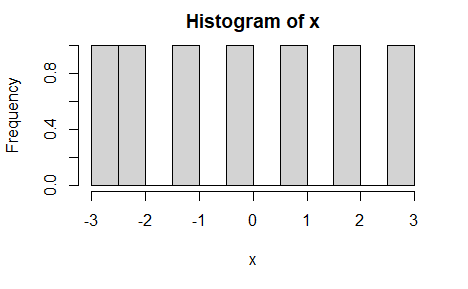

```r
hist(x, breaks=12, xlim=c(-3,3));
```

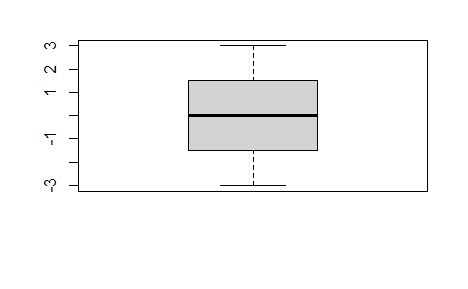

```r
boxplot(x);
```

```r
t.test(x, mu = 0, alternative="two.sided");
```

```
    One Sample t-test

data:  x
t = 0, df = 6, p-value = 1
alternative hypothesis: true mean is not equal to 0
95 percent confidence interval:
 -1.997895  1.997895
sample estimates:
mean of x
        0
```